# Methodology

## **The reproducible workflow**

The reproducible workflow is made up of the files: `00_library_n_prep.R`, `0_set_up_working_envrnmt.R`, `1_data_prep_general.R`, `2_segmentation_test_area_1.R`, `3_CV_segmentation_test_areas.R`, `4_segmentation_ROI.R`, `5_data_prep_classification_vtest_area_1.R`, `6_classification_test_area_1.R`, `7_data_prep_classification_ROI.R`, `8_classification_ROI` and `9_validation_test_area_1_ROI`.

These commented `.R files` build up on each other step-by-step, starting with the pre-processing of the input data. This `.Rmd` only presents the backbone which links the `.R files` together.

To reproduce the results of the whole project you have to run the code in the .R files, numbered sequentially. `00_library_n_prep.R` is a library file, containing all the packages needed for this project. It installs packages from the R repository or from github if some would be missing. This file does not need running, unlike the next one, `0_set_up_working_envrnmnt.R`. It is going to set up the project folder structure on your computer/laptop, but you have to adapt the path of the project directory to the destined place on your computer/laptop and also attach or install the packages needed. The data used in this project is stored on Google Drive, from where you have to download it to the respective folders (**dsm/**, **dem/**, **RGB_IR/**, **RGB_IR/**, **treepos/**, **train/**) set up on you device by the script you just ran (because a)**github** limits the size of data to be uploaded and b) the data used is not openly available, that is proprietary).

The main workflow consist of to sub-workflows, which are equally important: the Object Based Image Analysis (OBIA - `.R files 2-3-4`, working with the LiDAR data set) and the Pixel-Based Image Classification (PBIA - `.R files 5-6-7-8`, working with the Satellite data set), which will be combined at the end (`.R file 9`).

The .R files are commented in a manner, that they can be used as a manual or tutorial. In this chapter only the ideas behind the workflow and in the next chapter the results will be discussed to keep it short.

For this project three R packages were developed: `CENITH`, `LEGION` and `IKARUS`. `CENITH` is a wrapper for the `ForestTools` package (Plowright and Roussel 2020) to perform tree segmentation on a specific area. It also provides cross validation to estimate and validate the performance of a segmentation model for multiple test areas. See more details in the help pages and in the tutorial of the package. `LEGION` computes indices from RGB and Multispectral Imagery and provides also their basic statistics (correlation and homogeneity). See more details in the help pages and in the tutorial of the package. `IKARUS` is a wrapper for the `CAST` package (Meyer 2020) to perform Pixel-based Image Analysis and classification.See more details in the help pages and in the tutorial of the package.

## **General data preparation (`.R file: 1_data_prep_general.R`)**

For the project a Region of Interest (later ROI) was chosen which displays the different vegetation types at this specific ATE. Four test areas were defined within the ROI. The workflow is designed in such a way, that the individual steps of the workflow were developed on test area 1 and tested (generalized) on the other (test) areas to deal with the unavoidable variability of data. The resulting settings and variables are then to applied to the ROI. This three-step procedure is used to make sure that the algorithms applied and values used are effective and robust.

Originally masks for each 4 test areas were created in QGIS and based on them, the Canopy Height Model (CHM) and the RGB and IR (Infra-Red) imagery was cropped to the size of the test area masks. When it became clear, that the minimal computable raster size (on grounds of the restrictions of the ‘raster’ package in R) was a lot smaller than the maximum size of the actual ROI originally decided, it was reduced. The sizes of the CHM test areas were defined using the **‘Clip raster by Extent’** tool, with the *‘use map canvas’* setting in QGIS, to define 4, approximately 32 x 32 m test areas. Then the respective CHM test areas were used as masks/extents to clip the respective RGB and IR test areas in QGIS.

The CHM was created by subtracting the Digital Elevation Model (DEM) form the Digital Surface Model (DSM). This way only the LiDAR points connected to the vegetation above ground are preserved and can be used for our calculations.

## **Segmentation of the test area 1**

**(`2_segmentation_test_area_1.R`)**

With R script 2 the first sub-workflow, the Object-based Image Analysis of test area 1 is started. The aim of this first step is to find an accurate segmentation for test area 1 which can be tested on the other test areas and then applied to the ROI.

The segmentation is performed using the `CENITH` package. As `CENITH` is a wrapper for `ForestTools`, it also uses the *‘Watershed Segmentation’* using markers (Meyer and Beucher 1990) which is implemented in `ForestTools`. *‘Watershed Segmentation’* is an *‘Edge-based Region Growing Segmentation’* technique and simulates real-life flooding. It identifies clear segment boundaries which it then “fills up”. Markers guide the algorithm how/ from which point to “fill up” the basins/segments (**Figure 5**, Roffler 2020, 33).

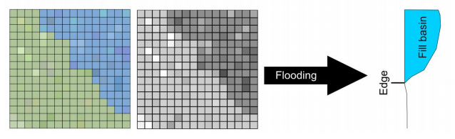

Operating principle of the ‘Watershed Segmentation’ Roffler 2020, 33.

The first task is to set verification points (this can be also done with the `ForestTools package`, but we preferred to do it by hand so it was not implemented in the `CENITH package`) - that is locate the positions of the trees (we will call it tree positions but technically they are verification points, that is ‘vp’) in the test areas using QGIS.

Before starting to define the tree positions in each test areas, first of all the minimum height of the trees has to be identified (which of course is region and area dependent). In the Alpine region the vegetation consists of trees but also shrubs and Krummholz, which have to be distinguished from trees. If also young trees trees are present and should be considered, then it is important not to confuse them with shrubs, which is often rather complicated and even impossible. If Satellite Imagery is also available (as in our case), it can help to consider the difference in the spectral and textural signature. The identification of the minimum tree-height can be best determined using QGIS. Thus to distinguish the actual trees, for one the spectral information of the Satellite Imagery (which will be mainly used for the Pixel-based Image Classification) was exploited. Trees demonstrate - apart from their height in the CMHs - much more branches which leads to less homogeneous green color (mixed with black and creme colored pixels) as that of the shrubs which show in their entirety a single color. On the other side the CHMs were displayed by giving each height between < 0.5 m and > 29 ma different color (see the QGIS style file). Combining these two sets of information, the minimum tree height was defined at 4-5 meters (**Figure 6**). This height included the lowest young trees but not the shrubs and Krummholz. To be able to include the young trees, it was opted for h=4 instead of 5 meters.

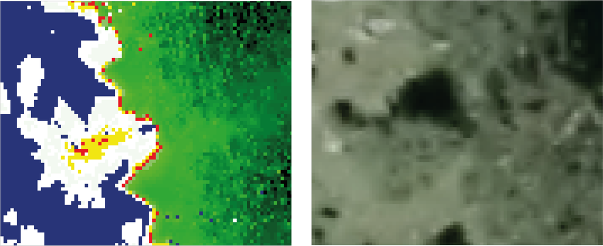

Comparision of RGB Satellite Imagery and LIDAR-derived CHMs classified by height using different colors (blue < o.5 m; white > 0.5 < 3; yellow > 3 < 4m, red > 4 < 5m; green to black < 5m) Detail of test area 4.

The exact position of the individual trees (including young trees) was based for on on the decision of the minimum tree height based on the RGB and IR Satellite Imagery and was determined by looking for the highest point of the chms (**Figure 7**).

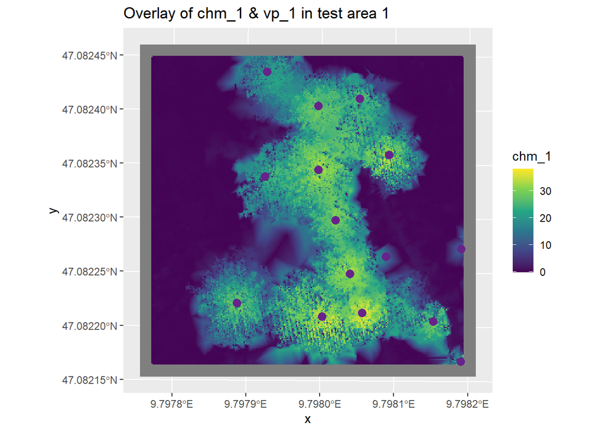

The segmentation itself can be executed with the `CENITH::TreeSeg` function. This function works with a MovingWindow of size a * b (x,y) at height h. `a`, `b` are horizontal and vertical values (x, y) in meters and `h` is height in meters on the CHM. This function takes single values, with which different and various values of the segmentation variable can be tested. The results can be checked in QGIS. The variables `MIN` and `MAX` filter the segments to a certain size. Because with the variables used there is small chance to get too big segments, the `MAX` variable is not used, only the `MIN` variable, to filter out small segments. Another variable, which controls and filters out small artifacts and data errors - directly on the chm is the `chmFilter`. The tests with `CENITH::TreeSeg` show (*2.3* - these numbers refer to the respective section in the code), that it is very useful to apply a `sum filtered` CHM (see the difference between the results **test_0** and **test_1** in QGIS) and give an estimate of how big or small the variables `a`, `b` and `MIN` have to be set. Based on the fact that there are 15 trees in test area 1 we can estimate how accurate the segments might be. Taking a look at test 1, 2 & 3 we can see how the reduction of `a` and `b` elevated the number of trees. This is useful information for `CENITH::BestSegVal`.

The function `CENITH::BestSegVal` can be fed with long sequences of values for each variable (this is called parameter tuning). N.B. long sequences mean longer calculation time, thus it is best to test out different variable settings with `CENITH::TreeSeg` to narrow down in which setting range a, b and h might move. In the second part of the script `2_segmentation_test_area_1.R`, the use of `CENITH::BestSegVal` is demonstrated (*2.4*). In this function also the vps (tree positions) are taken into account as a validation basis. All calculation in the resulting table are based on the comparison of the vps/tree positions to the segmentation results. The variable `hit.vp` shows explicitly, how many vps/tree positions are ‘hit’ by the resulting segments.

In the first run the values `a=seq(0.05, 0.1, 0.01), b=seq(0.05, 0.1, 0.01), h=seq(3.5, 6, 0.5), MIN=seq(0.1, 0.5, 0.1)` were tested, to go a bit below and above the defined height of the trees and to determine the best `a`, `b` and `MIN` values. `CHMfilter` is set at 3, because we want to do only minimal filtering to minimize small artifacts and gaps in the chm.

Results of the second run of CENITH::BestSegVal

| a | b | height | total_seg | hit.vp | under | over | area | hitrate | underrate | overrate | Seg_qualy | MIN | chm |
| --- | --- | --- | --- | --- | --- | --- | --- | --- | --- | --- | --- | --- | --- |
| 0.07 | 0.07 | 3.5 | 20 | 11 / 15 | 2 | 7 | 543.1406 | 0.7333333 | 0.1000000 | 0.3500000 | 0.73 @ 0.28 | 0.1 | chm_1_3 |
| 0.07 | 0.08 | 3.5 | 20 | 11 / 15 | 2 | 7 | 543.1406 | 0.7333333 | 0.1000000 | 0.3500000 | 0.73 @ 0.28 | 0.1 | chm_1_3 |
| 0.07 | 0.09 | 3.5 | 20 | 11 / 15 | 2 | 7 | 543.1406 | 0.7333333 | 0.1000000 | 0.3500000 | 0.73 @ 0.28 | 0.1 | chm_1_3 |
| 0.07 | 0.07 | 4.0 | 20 | 11 / 15 | 2 | 7 | 535.0156 | 0.7333333 | 0.1000000 | 0.3500000 | 0.73 @ 0.28 | 0.1 | chm_1_3 |
| 0.07 | 0.08 | 4.0 | 20 | 11 / 15 | 2 | 7 | 535.0156 | 0.7333333 | 0.1000000 | 0.3500000 | 0.73 @ 0.28 | 0.1 | chm_1_3 |
| 0.07 | 0.09 | 4.0 | 20 | 11 / 15 | 2 | 7 | 535.0156 | 0.7333333 | 0.1000000 | 0.3500000 | 0.73 @ 0.28 | 0.1 | chm_1_3 |
| 0.07 | 0.10 | 3.5 | 19 | 11 / 15 | 2 | 6 | 543.1562 | 0.7333333 | 0.1052632 | 0.3157895 | 0.73 @ 0.26 | 0.1 | chm_1_3 |
| 0.07 | 0.10 | 4.0 | 19 | 11 / 15 | 2 | 6 | 535.0156 | 0.7333333 | 0.1052632 | 0.3157895 | 0.73 @ 0.26 | 0.1 | chm_1_3 |

## **Cross-validated Segmentation of the test areas**

**(`3_CV_segmentation_test_areas.R`)**

Results of the cross-validations cv1 - cv8

| cv1 | sites | a | b | height | total_seg | hit | vp | under | over | area | hitrate | underrate | overrate | Seg_qualy |
| --- | --- | --- | --- | --- | --- | --- | --- | --- | --- | --- | --- | --- | --- | --- |
| 1 | chm_1 | 0.07 | 0.07 | 4 | 20.0 | 11.00 | 15.00 | 2.0 | 7.00 | 535.0156 | 0.7333333 | 0.1000000 | 0.3500000 | 0.73 @ 0.28 |
| 2 | chm_2 | 0.07 | 0.07 | 4 | 28.0 | 10.00 | 12.00 | 1.0 | 17.00 | 421.0312 | 0.8333333 | 0.0357143 | 0.6071429 | 0.83 @ 0.34 |
| 3 | chm_3 | 0.07 | 0.07 | 4 | 40.0 | 16.00 | 18.00 | 1.0 | 23.00 | 605.9531 | 0.8888889 | 0.0250000 | 0.5750000 | 0.89 @ 0.31 |
| 4 | chm_4 | 0.07 | 0.07 | 4 | 22.0 | 8.00 | 12.00 | 2.0 | 12.00 | 369.2031 | 0.6666667 | 0.0909091 | 0.5454545 | 0.67 @ 0.36 |
| 5 | Mean | 0.07 | 0.07 | 4 | 27.5 | 11.25 | 14.25 | 1.5 | 14.75 | 482.8008 | 0.7805556 | 0.0629058 | 0.5193994 | 0.78 @ 0.32 |

| cv2 | sites | a | b | height | total_seg | hit | vp | under | over | area | hitrate | underrate | overrate | Seg_qualy |
| --- | --- | --- | --- | --- | --- | --- | --- | --- | --- | --- | --- | --- | --- | --- |
| 1 | chm_1 | 0.07 | 0.08 | 3.5 | 20.00 | 11.00 | 15.00 | 2.0 | 7.0 | 543.1406 | 0.7333333 | 0.1000000 | 0.3500000 | 0.73 @ 0.28 |
| 2 | chm_2 | 0.07 | 0.08 | 3.5 | 28.00 | 10.00 | 12.00 | 1.0 | 17.0 | 443.3438 | 0.8333333 | 0.0357143 | 0.6071429 | 0.83 @ 0.34 |
| 3 | chm_3 | 0.07 | 0.08 | 3.5 | 43.00 | 16.00 | 18.00 | 1.0 | 26.0 | 623.5000 | 0.8888889 | 0.0232558 | 0.6046512 | 0.89 @ 0.33 |
| 4 | chm_4 | 0.07 | 0.08 | 3.5 | 22.00 | 8.00 | 12.00 | 2.0 | 12.0 | 377.0000 | 0.6666667 | 0.0909091 | 0.5454545 | 0.67 @ 0.36 |
| 5 | Mean | 0.07 | 0.08 | 3.5 | 28.25 | 11.25 | 14.25 | 1.5 | 15.5 | 496.7461 | 0.7805556 | 0.0624698 | 0.5268121 | 0.78 @ 0.33 |

| cv3 | sites | a | b | height | total_seg | hit | vp | under | over | area | hitrate | underrate | overrate | Seg_qualy |
| --- | --- | --- | --- | --- | --- | --- | --- | --- | --- | --- | --- | --- | --- | --- |
| 1 | chm_1 | 0.07 | 0.09 | 3.5 | 20.0 | 11.00 | 15.00 | 2.0 | 7.00 | 543.1406 | 0.7333333 | 0.1000000 | 0.3500000 | 0.73 @ 0.28 |
| 2 | chm_2 | 0.07 | 0.09 | 3.5 | 27.0 | 10.00 | 12.00 | 1.0 | 16.00 | 443.4219 | 0.8333333 | 0.0370370 | 0.5925926 | 0.83 @ 0.33 |
| 3 | chm_3 | 0.07 | 0.09 | 3.5 | 42.0 | 16.00 | 18.00 | 1.0 | 25.00 | 623.5156 | 0.8888889 | 0.0238095 | 0.5952381 | 0.89 @ 0.32 |
| 4 | chm_4 | 0.07 | 0.09 | 3.5 | 21.0 | 8.00 | 12.00 | 2.0 | 11.00 | 377.0156 | 0.6666667 | 0.0952381 | 0.5238095 | 0.67 @ 0.36 |
| 5 | Mean | 0.07 | 0.09 | 3.5 | 27.5 | 11.25 | 14.25 | 1.5 | 14.75 | 496.7734 | 0.7805556 | 0.0640212 | 0.5154101 | 0.78 @ 0.32 |

| cv4 | sites | a | b | height | total_seg | hit | vp | under | over | area | hitrate | underrate | overrate | Seg_qualy |
| --- | --- | --- | --- | --- | --- | --- | --- | --- | --- | --- | --- | --- | --- | --- |
| 1 | chm_1 | 0.07 | 0.07 | 3.5 | 20.00 | 11.00 | 15.00 | 2.0 | 7.0 | 543.1406 | 0.7333333 | 0.1000000 | 0.3500000 | 0.73 @ 0.28 |
| 2 | chm_2 | 0.07 | 0.07 | 3.5 | 28.00 | 10.00 | 12.00 | 1.0 | 17.0 | 443.3438 | 0.8333333 | 0.0357143 | 0.6071429 | 0.83 @ 0.34 |
| 3 | chm_3 | 0.07 | 0.07 | 3.5 | 43.00 | 16.00 | 18.00 | 1.0 | 26.0 | 623.5000 | 0.8888889 | 0.0232558 | 0.6046512 | 0.89 @ 0.33 |
| 4 | chm_4 | 0.07 | 0.07 | 3.5 | 22.00 | 8.00 | 12.00 | 2.0 | 12.0 | 377.0000 | 0.6666667 | 0.0909091 | 0.5454545 | 0.67 @ 0.36 |
| 5 | Mean | 0.07 | 0.07 | 3.5 | 28.25 | 11.25 | 14.25 | 1.5 | 15.5 | 496.7461 | 0.7805556 | 0.0624698 | 0.5268121 | 0.78 @ 0.33 |

| cv5 | sites | a | b | height | total_seg | hit | vp | under | over | area | hitrate | underrate | overrate | Seg_qualy |
| --- | --- | --- | --- | --- | --- | --- | --- | --- | --- | --- | --- | --- | --- | --- |
| 1 | chm_1 | 0.07 | 0.08 | 4 | 20.0 | 11.00 | 15.00 | 2.0 | 7.00 | 535.0156 | 0.7333333 | 0.1000000 | 0.3500000 | 0.73 @ 0.28 |
| 2 | chm_2 | 0.07 | 0.08 | 4 | 28.0 | 10.00 | 12.00 | 1.0 | 17.00 | 421.0312 | 0.8333333 | 0.0357143 | 0.6071429 | 0.83 @ 0.34 |
| 3 | chm_3 | 0.07 | 0.08 | 4 | 40.0 | 16.00 | 18.00 | 1.0 | 23.00 | 605.9531 | 0.8888889 | 0.0250000 | 0.5750000 | 0.89 @ 0.31 |
| 4 | chm_4 | 0.07 | 0.08 | 4 | 22.0 | 8.00 | 12.00 | 2.0 | 12.00 | 369.2031 | 0.6666667 | 0.0909091 | 0.5454545 | 0.67 @ 0.36 |
| 5 | Mean | 0.07 | 0.08 | 4 | 27.5 | 11.25 | 14.25 | 1.5 | 14.75 | 482.8008 | 0.7805556 | 0.0629058 | 0.5193994 | 0.78 @ 0.32 |

| cv6 | sites | a | b | height | total_seg | hit | vp | under | over | area | hitrate | underrate | overrate | Seg_qualy |
| --- | --- | --- | --- | --- | --- | --- | --- | --- | --- | --- | --- | --- | --- | --- |
| 1 | chm_1 | 0.07 | 0.09 | 4 | 20.00 | 11.00 | 15.00 | 2.0 | 7 | 535.0156 | 0.7333333 | 0.1000000 | 0.3500000 | 0.73 @ 0.28 |
| 2 | chm_2 | 0.07 | 0.09 | 4 | 27.00 | 10.00 | 12.00 | 1.0 | 16 | 421.1094 | 0.8333333 | 0.0370370 | 0.5925926 | 0.83 @ 0.33 |
| 3 | chm_3 | 0.07 | 0.09 | 4 | 39.00 | 16.00 | 18.00 | 1.0 | 22 | 605.9531 | 0.8888889 | 0.0256410 | 0.5641026 | 0.89 @ 0.31 |
| 4 | chm_4 | 0.07 | 0.09 | 4 | 21.00 | 8.00 | 12.00 | 2.0 | 11 | 369.2344 | 0.6666667 | 0.0952381 | 0.5238095 | 0.67 @ 0.36 |
| 5 | Mean | 0.07 | 0.09 | 4 | 26.75 | 11.25 | 14.25 | 1.5 | 14 | 482.8281 | 0.7805556 | 0.0644790 | 0.5076262 | 0.78 @ 0.32 |

| cv7 | sites | a | b | height | total_seg | hit | vp | under | over | area | hitrate | underrate | overrate | Seg_qualy |
| --- | --- | --- | --- | --- | --- | --- | --- | --- | --- | --- | --- | --- | --- | --- |
| 1 | chm_1 | 0.07 | 0.1 | 3.5 | 19.0 | 11.00 | 15.00 | 2.0 | 6.00 | 543.1562 | 0.7333333 | 0.1052632 | 0.3157895 | 0.73 @ 0.26 |
| 2 | chm_2 | 0.07 | 0.1 | 3.5 | 26.0 | 10.00 | 12.00 | 1.0 | 15.00 | 443.4688 | 0.8333333 | 0.0384615 | 0.5769231 | 0.83 @ 0.33 |
| 3 | chm_3 | 0.07 | 0.1 | 3.5 | 41.0 | 16.00 | 18.00 | 1.0 | 24.00 | 623.5781 | 0.8888889 | 0.0243902 | 0.5853659 | 0.89 @ 0.32 |
| 4 | chm_4 | 0.07 | 0.1 | 3.5 | 20.0 | 8.00 | 12.00 | 2.0 | 10.00 | 377.0312 | 0.6666667 | 0.1000000 | 0.5000000 | 0.67 @ 0.35 |
| 5 | Mean | 0.07 | 0.1 | 3.5 | 26.5 | 11.25 | 14.25 | 1.5 | 13.75 | 496.8086 | 0.7805556 | 0.0670287 | 0.4945196 | 0.78 @ 0.31 |

| cv8 | sites | a | b | height | total_seg | hit | vp | under | over | area | hitrate | underrate | overrate | Seg_qualy |
| --- | --- | --- | --- | --- | --- | --- | --- | --- | --- | --- | --- | --- | --- | --- |
| 1 | chm_1 | 0.07 | 0.1 | 4 | 19.00 | 11.00 | 15.00 | 2.0 | 6 | 535.0156 | 0.7333333 | 0.1052632 | 0.3157895 | 0.73 @ 0.26 |
| 2 | chm_2 | 0.07 | 0.1 | 4 | 26.00 | 10.00 | 12.00 | 1.0 | 15 | 421.1406 | 0.8333333 | 0.0384615 | 0.5769231 | 0.83 @ 0.33 |
| 3 | chm_3 | 0.07 | 0.1 | 4 | 38.00 | 16.00 | 18.00 | 1.0 | 21 | 605.9531 | 0.8888889 | 0.0263158 | 0.5526316 | 0.89 @ 0.3 |
| 4 | chm_4 | 0.07 | 0.1 | 4 | 20.00 | 8.00 | 12.00 | 2.0 | 10 | 369.2500 | 0.6666667 | 0.1000000 | 0.5000000 | 0.67 @ 0.35 |
| 5 | Mean | 0.07 | 0.1 | 4 | 25.75 | 11.25 | 14.25 | 1.5 | 13 | 482.8398 | 0.7805556 | 0.0675101 | 0.4863360 | 0.78 @ 0.31 |

## **Segmentation of ROI (`4_segmentation_ROI.R`)**

Given the explanatory aim of this work, all eight results of `best_seg_vp_1_filt_v2_filt` (created in Chapter 3.4 and tested on all 4 test areas in Chapter 3.5) were applied to the ROI. The segmentation results, obtained with `CENITH::TreeSeg`, can be visually inspected and compared in QGIS. It became swiftly clear (as expected), that h=3.5 m is too low as tree height because it may result in segmenting some of the shrub as well (note the different colors of the chm heights in QGIS). Because of the similar height of the seedlings and young trees and shrubs it is practically impossible to distinguish shrubs and seedlings based purely on height (as discussed before) and thus the choice of 4 m as tree height was not revised.

But what happens with heights above 4 m? 4.5, 5 and 5.1 m (`segm_ROI9` to `segm_ROI_12`) were tested to test if the results of `segm_ROI_8` can be refined. With a tree-height over 4 m, the number of charted young trees and the tree crown area is decreasing. Thus the optimal result is `segm_ROI_8`. You can see the results of the segmentations in the respective script. It has to be underlined, that the chosen segmentation `segm_ROI_8` is of course not perfect - the result is approximately **78% accuracy** and it could be improved by choosing smaller steps of `h` e.g (**Figure 8**). It has to be said that it makes no real sense to thoroughly compare the segmentation results with the RGB Imagery - rather the IR Imagery. The segmentation is based on the Canopy Height Model and LiDAR data and the RGB and IR Imagery on spectral data. E.g. in the IR Imagery you can see the young trees and seedling in a lighter red.

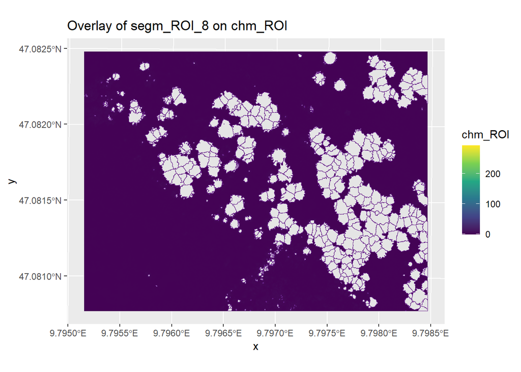

The most fitting segmentation of the ROI.

## **Data preparation for the Classification of test area 1 (`5_data_prep_classification_test_area_1.R`)**

With R script 5 the second sub-workflow, the Pixel-based Image Analysis of test area 1 is started. In this first step the RGB (`RGB_1`), IR Imagery (`IR_1`) and combined (`RGBNIR_1`) is prepared for the classification/prediction. The aim of this first step is to test settings for test area 1 which can be applied to the ROI.  
This data preparation for PBIA is performed by using the `LEGION package` by computing RGB (`LEGION::vegInd_RGB`) and multi-spectral (MS, `LEGION::vegInd_mspec`) indices which can be filtered and then tested on correlation (*5.3*). Indices are used to enhance the spectral differences between the different object classes (*1-tree, 2-shrubs, 3-grass, 4-tree in shadow, 5-shadow* and *6-stone*) which are to be detected. Currently 11 RGB and 4 MS indices are implemented. During the testing it was understood, that certain indices (`VARI`, `RI` and `HI`) contain ample homogeneous areas (**Figure 9**). Including these indices in further calculations would distort the results and deform the prediction.

```
##
## ### LEGION calculating (Visible Vegetation Index (VVI)) ###
##
## ### LEGION calculating (Visible Atmospherically Resistant Index (VARI)) ###
##
## ### LEGION calculating (Normalized difference turbidity index (NDTI)) ###
##
## ### LEGION calculating (Redness index (RI)) ###
##
## ### LEGION calculating (Soil Colour Index (CI)) ###
##
## ### LEGION calculating (Brightness Index (BI)) ###
##
## ### LEGION calculating (Spectra Slope Saturation Index (SI)) ###
##
## ### LEGION calculating (Primary colours Hue Index (HI)) ###
##
## ### LEGION calculating (Triangular greenness index (TGI)) ###
##
## ### LEGION calculating (Green leaf index (GLI)) ###
##
## ### LEGION calculating (Normalized green red difference index  (NGRDI)) ###
##
## ###########################
## ### The LEGION is ready ###
```

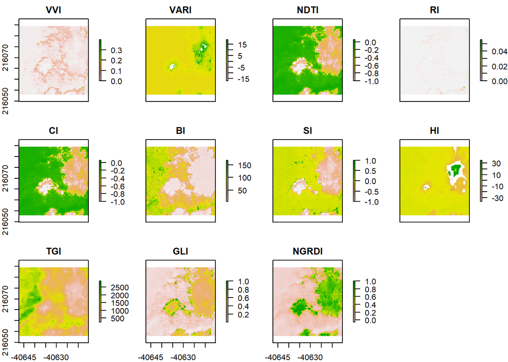

The computed 11 RGB Indices of test area 1.

To solve the problem of homogeneity in broad areas in indices, a step for testing for homogeneity was implemented by the use `LEGION::detct_RstHmgy` function (*5.5*). The function works with `valueRange` which sets the value for in how much percentage the data is distributed in the raster. `THvalue` sets the threshold of homogeneity.  
First `ALL_ind_stack_1` was tested with homogeneity thresholds between 0.4 and 0.9. The settings `valueRange = 0.1` and `THvalue = 0.9` led to drop exactly those three indices which demonstrated ample homogeneous areas: `VARI, RI` and `HI`. Thus they were removed statistically. These settings were applied also to `ALL_RGBMS_stack_1`, creating `ALL_RGBMS_stack_1_homog09` (and `ALL_ind_stack_1_homog09`).

To create different textural representations of the training data for the classification, different spatial filters are applied to the raster stacks `ALL_ind_stack_1_homog09` and `ALL_RGBMS_stack_1_homog09`, using the `LEGION::filter_Stk` function (*5.6*). Filter enhance special properties of indices and the overall homogeneity of spectral areas and enhance the edges and between the different objects. The filters `sum, min, max, sd, mean, modal, sobel , sobel_hrzt` and `sobel_vert` have been implemented and used. How they work is described in the Help of the function. `ALL_ind_stack_1_homog09_filt` yielded **108** and `ALL_RGBMS_stack_1_homog09_filt` **144** filtered spectral raster.

Another data preparation task, but independent from the preparation of the spectral data is the generation of training polygons. In other works shape files with examples of the spectral classes in training area 1 were prepared in QGIS. The different classes are: *1-tree, 2-shrubs, 3-grass, 4-tree in shadow, 5-shadow* and *6-stone*. Two training shapes were created, to compare a brute-force approach using minimal number of arbitrary sized and shaped coarse training polygons (1 polygon/class, `train_2`) to accurate, 3x3 pixel training polygons (`train_1`). `train_1` consists of 43 polygons, of which the classes *1-tree*, *4-tree_in shadow* and *5-shadow* (which have a more complicated spectral signature and are especially interesting from the point of view of the project) are present 10 instances each, classes *3-grass* and *2-shrubs* present 5 instances each and class *6-stone* presents 3 instances (**Figure 10**).

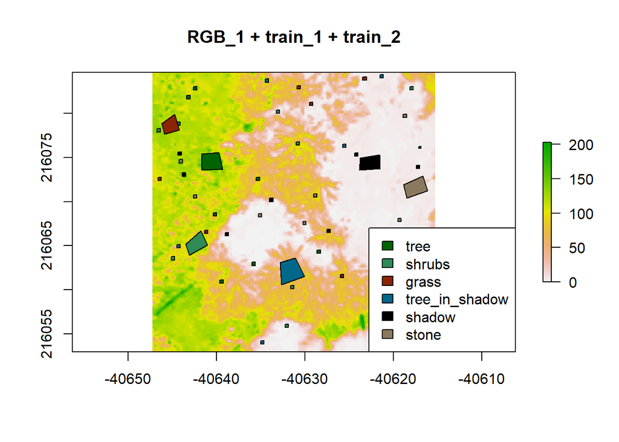

The training shapes train 1 and train 2 projected on RGB Satellite Imagery of test area 1.

## **Classification of test area 1 (`6_classification_test_area_1.R`)**

The aim of this step is to find an accurate classification for test area 1 which can be then applied to the ROI.

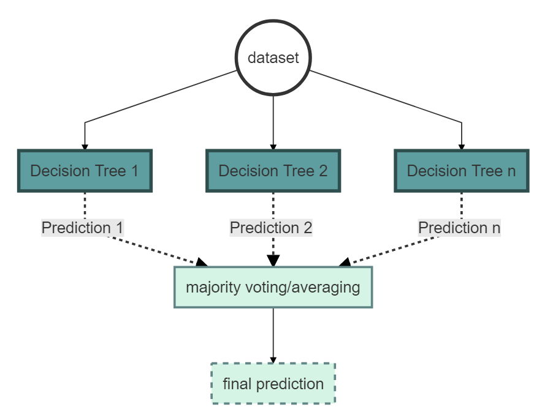

Work mechanism of the Random Forest Algorithm.

There are two important step before the actual machine learning can be started. One is the creation of meaningful **training data sets** and the other is the choice of most meaningful predictors and data dimension reduction.

The spectral predictors (`clean_ALL_ind_stack_1_homog09_filt/predictors 1` with **18 layers**, `clean_ALL_RGBMS_stack_1_homog09_filt/predictors 2` with **19 layers**) and the training polygons have been created in the previous steps. In the case of the spectral predictors all precautions were taken to create unbiased predictors (*5.5 - 5.7*) and in the case of the training polygons different amount, shape and size make them a good comparison of brute force and carefully considered polygons. These constitute the fundament of the two data sets which will serve as input for the machine learning algorithm.

First, values for all defined 6 classes have to be extracted from the predictors into a data frame. This is done using the `IKARUS::exrct_Traindat` function (*6.2.1*). By working with two training polygons and two spectral predictor stacks, altogether four **initial training data frames** (`train1_pred1`, `train1_pred2`, `train2_pred1` and `train2_pred2`) were created.

To accelerate and enhance the effectiveness of the machine learning algorithm, the most meaningful predictors are chosen by the `IKARUS::BestPredFFS` function from the just created four training data sets (*6.2.2*). This function is a wrapper for the `CAST::ffs` function, which uses **FFS**, that is *‘Forward Feature Selection’* (Meyer et al. 2018) that is a data analysis method which identifies predictors which can lead to over-fitting in models. `IKARUS::BestPredFFS` calculates all possible models from the input training data set and looks for the model with the least number of predictors but the best performance . This model is the output of the `IKARUS::BestPredFFS`function (in our case `FFS_1 - FFS_4`). `FFS_1$selectedvars` accesses the list of best performing predictors. `IKARUS::BestPredFFS` also saves processing time by eliminating the less conclusive and possibly still biased predictors.

Once provided with the information of the best performing and most meaningful predictors selected by `IKARUS::BestPredFFS`, two **final training data sets** are prepared as input for the machine learning.  
The first data set is the training data frame (`train_FFS_1 - train_FFS_4`) with the *response*/*dependent variable*, that is the `classes` we want to predict and the extracted values from the *independent variables* or `predictors` (by the shape files, in step 6.2.1), selected by `IKARUS::BestPredFFS`. It was created by extracting the chosen predictor columns and the class column from the initial data frame.  
The second data set is the predictor stack (`predictors_FFS_1 - predictors_FFS_4`), which are selected predictors by `IKARUS::BestPredFFS`.

The machine learning model building and classification is executed by the function `IKARUS::RFclass`. It builds a model and performs a *‘Random Forest’* classification in one step. These two procedures are often also carried out separately. `IKARUS::RFclass` is a wrapper for `caret::train` with 5-fold cross-validation and *‘Random Forest’* as classification algorithm. The two **final training data sets** `train_FFS_1 - train_FFS_4` and `predictors_FFS_1 - predictors_FFS_4` are handed to this function. The results are the model used for the prediction and the prediction itself.

When inspecting the prediction results, the first thing that catches the eye is that **predictions 3 and 4** yield the same results. When we look at the result of `IKARUS::BestPredFFS`, the *‘Forward Feature Selection’*, it becomes clear, that the stacks consist of the same predictors (`NDVI_min3` and `TGI_max3`). If we go back to the spectral predictors (`clean_ALL_ind_stack_1_homog09_filt/predictors 1` and `clean_ALL_RGBMS_stack_1_homog09_filt/predictors 2`) created in step *5.7*, then we can recall, that they differed by 4 and 5 predictors. The predictors remaining after the *‘Forward Feature Selection’* were not of those which differed in the to spectral predictor set, but those which were present in both predictor sets. **Predictions 3 and 4** were carried out with training data sets which were created using the training shape file `train_2`, which consists of minimal number of arbitrary sized and shaped coarse training polygons. This means, that the big training shapes contained pixels which in fact belonged to more than one class made the classes less disparate and thus the differing 4 and 5 predictors did not deliver meaningful information for the best model and were sorted out by the *‘Forward Feature Selection’*.

**Predictions 1 and 2** were created using the accurate, 3x3 pixel training polygons of the shape file `train_1` and mainly differ in respect of the amount of pixels classified in specific classes. Prediction 1 is more accurate when compared to the actual distribution of the classified pixels. In **Prediction 2** more pixels were classified as tree instead of shrubs and sometimes grass. This is due to the fact that although the resolution of the pixels is 12,5 cm, the spectral representation of classes *tree*, *shrub* and *grass* is quite similar and these classes are hard to distinguish. This applies even more the classes *shadow* and *tree in shadow*. Considering all classes and their reflection in the classification, prediction 1 is delivers the best results.

Given the explanatory aim of this work, all steps which were applied to test area 1 were applied to the ROI. Because the steps are obviously the same, they are only mentioned in broad outline and only the differences are discussed in this chapter in depth. The data preparation for the classification can be described with the following steps: 7.1 Load spectral data 7.2 Stack `RGB_ROI`, `IR_ROI` and `RGBNIR_ROI` 7.3 Compute Indices with `LEGION::vegInd_RGB` and `LEGION::vegInd_mspec`

The indices `VARI`, `RI` and `HI` presented similarly ample homogeneous areas and it was possible to filter them out statistically.

Difference between predictors:

*predictors_ROI_1* “MSR_min3_ALL_ind_stack_ROI_homog093_filt_corr_09_pred_1”  
“TDVI_sobel3_ALL_ind_stack_ROI_homog093_filt_corr_09_pred_1”

*predictors_ROI_2* “Blue_min3_ALL_RGBMS_stack_ROI_homog093_filt_corr_09_pred_2”  
“IR_ROI_sobel3_ALL_RGBMS_stack_ROI_homog093_filt_corr_09_pred_2”